# Python3で書いたコードをexeにコンパイルしてみよう

## コンパイルの基礎知識

### コンパイルって何？

> コンパイルとは、プログラミング言語で書いた文字列（ソースコード）を  
> コンピュータ上で実行可能な形式（オブジェクトコード）に変換することです。

### ソースコードとは

> 簡単に言うと、今までの授業で書いてきたプログラム（文字列）は全てソースコードです。  
> Javaの授業ではeclipsというソフトを使ってJava言語を、  
> HTMLの授業ではBracketsというテキストエディタを使ってHTML5というマークアップ言語を書いてきました。

### オブジェクトコードとは

> オブジェクトコードとは、コンピュータが理解できる言語やコードです。  
> ソースコードは、人間が読むことはできますが、コンピューターは理解することができません。  
> 通常は人間が直接書くことはなく、ソースコードから変換して生成します。

### いや今までJavaの時実行ボタン押せば動いてくれてたじゃん

> 今までJavaの授業で書いたコードが動いてくれていたのは、eclipsのソフトがコンパイルしていてくれていたからです。  
> 実行ボタンを押すと自動でコンパイルして、コンソールに表示してくれていたということです。

### ついでにちょっと脱線して、もっとややこしい話(混乱したくない人は耳を閉じててください)

> 工藤先生は授業中に「Pythonはコンパイルが必要ない言語」と言っていました。  
> Pythonはインタプリタ型言語というもので、簡単に言うとコードを1行ずつ翻訳して実行する言語です。  
> そのため、いま使っているAnacondaのNotebookのようなソフトに依存して動きます。  
> 有名なC言語やC++言語はコンパイラ型言語というもので、簡単に言うとコードを全部丸ごと一気に翻訳して実行する言語です。  
> ちなみに、Java言語は特殊で、インタプリタ型言語でもコンパイラ型言語でもありません。  
> Java言語は、Java仮想マシン(eclipsの機能)の機械語に翻訳され，仮想マシン上で実行されます。  
> ちなみにちなみに、HTMLはマークアップ言語というものであり、、プログラム言語ではありません。

# 結局今日やるコンパイルって何？

今日は、インタプリタ型言語であるPythonを、Anacondaを頼らずに実行できる形に変換(コンパイル)していきます。

### 実行形式は、OSによって異なる

> 実行形式は、使用するコンピューターのOSによって異なります。  
> PC系だと  
> ・Windows→.exe形式  
> ・MacOS→.app形式  
> ・LinuxOS→.deb形式、.rpm形式など(ディストリビュージョンによって違うかも) (.....ちなみにCentOSはRedhat系)  
> モバイル系だと  
> ・ios→.ipa形式  
> ・Android→.apk形式  
> 今回は、WindowsOSで使用できる「exe」形式にコンパイルしていきます。

# AnacondaでPython3をexeにコンパイルする方法

今回は、インタプリタ型言語であるPythonを、Anacondaを頼らずに実行できる形に変換(コンパイル)していきます。  
Python で ファイルを exe化するには pyinstaller を使用します。  
まずはAnacondaに、【pyinstaller】 というライブラリ(追加機能)を追加していきます。

## pyinstallerのインストール手順

### AnacondaのEnvironmentsから、bass(root)→openterminalを選択します。

[figure not shown]

### terminalが起動したら、【pip install pyinstaller】と入力して、実行します。

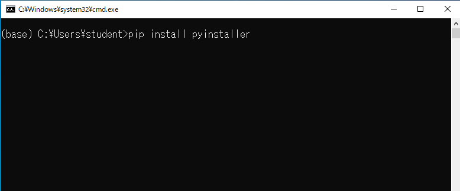

### 再び【(base) C:\Users\student>】と表示されたら、インストールは完了です。

# 早速コンパイルしてみよう

今回は、第1回目の授業で出された、ぽむぽむ問題のソースコードをexe化していきます。  
以下のコードを使用して、新しくNotebookを作ります。

```python
for i in range(2):
    try:
        number = int(input("文字列を入力してください:"))
    except ValueError:
        print("エラー：数字で入力してください")
    else:
        print("あなたの好きな数字は",number,"です")
```

```
文字列を入力してください:404
あなたの好きな数字は 404 です
文字列を入力してください:工藤健吾
エラー：数字で入力してください
```

### 分かりやすくするために、Desktop上に「reipomu」という名前で作ってください。

[figure not shown]

[figure not shown]

### File→Download asから、「.py形式」で保存します。

[figure not shown]

### ダウンロードフォルダに「reipomu.py」ファイルがあれば正しいです。

ダウンロードしたreipomu.pyファイルを、デスクトップに移動してください。

### AnacondaのTerminalを起動して、デスクトップのディレクトリに移動します。

データベースの授業でコマンドプロンプトの使い方は完璧なはず

[figure not shown]

### pyinstallerの起動コマンドは【pyinstaller ファイル名 --onefile】です。

今回コンパイルしたいファイル名はreipomu.pyなので、【pyinstaller reipomu.py --onefile】と入力して実行します。

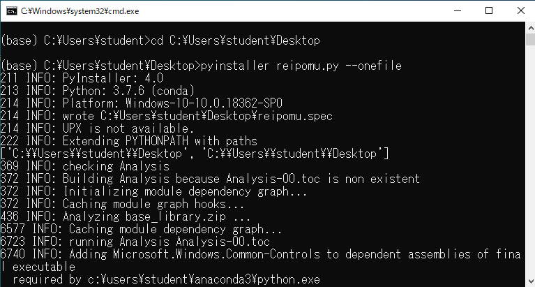

### 再び【(base) C:\Users\studen\Desktop>】と表示されたら、コンパイルは完了です。

デスクトップに様々なファイルが生成されていると思います。

### デスクトップの【dist】フォルダの中に、【reipomu.exe】が生成されています。

[figure not shown]

### ダブルクリックで実行してみましょう！

## これでPythonのexe化は完了です。

> このexeファイルはAnacondaなどに依存していないため、  
> exe形式を実行できる環境(WIndowsOS、Wineなど)ならどこでも実行することができます。  
> 簡単に言うと、Anacondaをインストールしていないパソコンでもreipomuが実行できます。

## エクストラまーちゃん問題(別に課題じゃないです)

### 今の手順だと、2回目のtryの実行が最後まで終了すると同時に、アプリケーションが終了してしまいます。

勝手にウインドウが閉じてしまうので、2回目の処理結果を見ることができません。

### 実行完了後処理を追加する

> 実行後、「終了するにはescを押してください。」と表示させる escキーを押すとプログラムを終了する  
> escキー以外のキーが押された場合、プログラムをもう一度実行する

#### ここまで書けば、結構「アプリケーションを開発してる!」という実感が湧くと思います。

#### 別に課題ではないので興味のある人だけやってみてください。